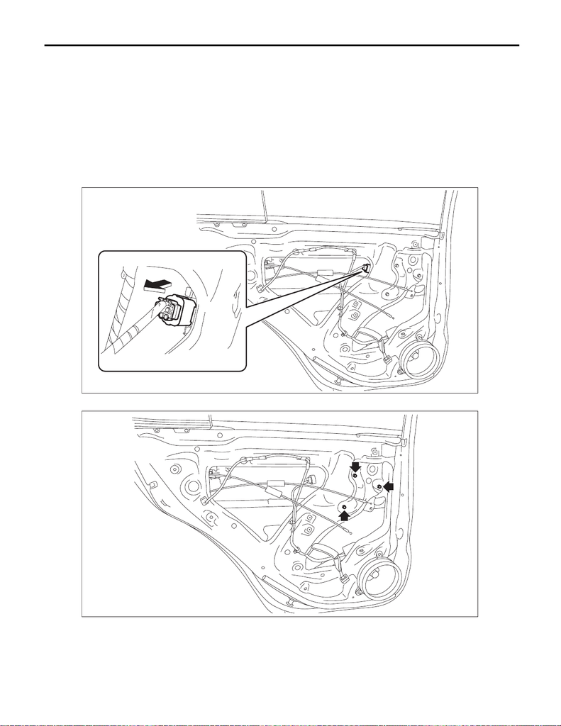

GW-37

Rear Regulator and Motor Assembly

GLASS/WINDOWS/MIRRORS

12.Rear Regulator and Motor Assembly

A: REMOVAL

1) Disconnect the ground cable from battery. <Ref. to NT-5, BATTERY, NOTE, Note.>

NOTE:

For models other than STI model, disconnect the ground terminal from battery sensor.

2) Remove the trim panel - rear door. <Ref. to EI-57, REAR DOOR, REMOVAL, Door Trim.>

3) Remove the sealing cover - rear door.

4) Remove the glass assembly - rear door. <Ref. to GW-34, REMOVAL, Rear Door Glass.>

5) Remove the rear regulator and motor assembly.

(1) Disconnect the connector of the motor - rear.

(2) Remove the bolts, and then remove the regulator and motor assembly - rear.

GW-01041

GW-01411

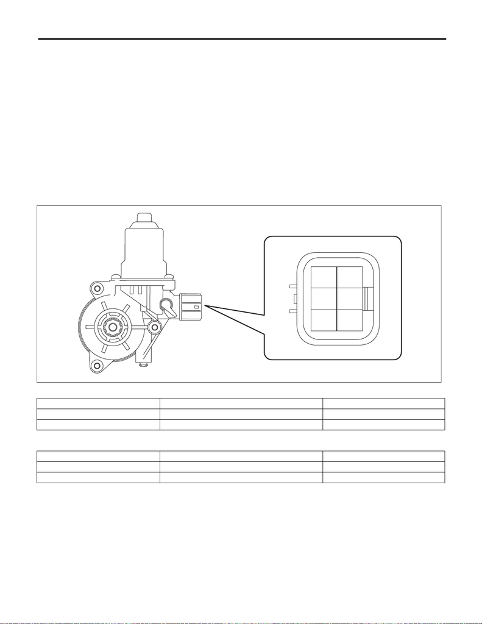

GW-38

Rear Regulator and Motor Assembly

GLASS/WINDOWS/MIRRORS

B: INSTALLATION

1) Install the regulator and motor assembly rear.

Tightening torque:

7.5 N·m (0.8 kgf-m, 5.5 ft-lb)

2) Install the glass assembly - rear door. <Ref. to GW-36, INSTALLATION, Rear Door Glass.>

3) Install the sealing cover - rear door.

4) Install the trim panel - rear door. <Ref. to EI-58, INSTALLATION, Door Trim.>

5) Connect the battery ground terminal. <Ref. to NT-5, BATTERY, NOTE, Note.>

NOTE:

For models other than STI model, connect the ground terminal to battery sensor.

C: INSPECTION

1) Disconnect the connector of the motor - rear.

•LH side

• RH side

3) If it does not operate properly as a result of inspection, replace the regulator and motor assembly - rear.

Terminal No. Inspection conditions Standard

4 (+) — 1(–) Apply battery voltage between terminals. Increase

1 (+) — 4(–) Apply battery voltage between terminals. Decrease

Terminal No. Inspection conditions Standard

3 (+) — 6(–) Apply battery voltage between terminals. Increase

6 (+) — 3(–) Apply battery voltage between terminals. Decrease

GW-01030

1

2

3

4

5

6